```python
import pandas as pd
hr_df = pd.read_csv("./data/HR_comma_sep.csv")
```

```python
hr_df.head(4)
```

|  | satisfaction_level | last_evaluation | number_project | average_montly_hours | time_spend_company | Work_accident | left | promotion_last_5years | sales | salary |
| --- | --- | --- | --- | --- | --- | --- | --- | --- | --- | --- |
| 0 | 0.38 | 0.53 | 2 | 157 | 3 | 0 | 1 | 0 | sales | low |
| 1 | 0.80 | 0.86 | 5 | 262 | 6 | 0 | 1 | 0 | sales | medium |
| 2 | 0.11 | 0.88 | 7 | 272 | 4 | 0 | 1 | 0 | sales | medium |
| 3 | 0.72 | 0.87 | 5 | 223 | 5 | 0 | 1 | 0 | sales | low |

# Employee likely to leave

1. Salary
2. No promotion
3. job satisfaction
4. Ratings
5. no of years spent in company

```python
hr_df.info()
```

```
<class 'pandas.core.frame.DataFrame'>
RangeIndex: 14999 entries, 0 to 14998
Data columns (total 10 columns):
satisfaction_level       14999 non-null float64
last_evaluation          14999 non-null float64
number_project           14999 non-null int64
average_montly_hours     14999 non-null int64
time_spend_company       14999 non-null int64
Work_accident            14999 non-null int64
left                     14999 non-null int64
promotion_last_5years    14999 non-null int64
sales                    14999 non-null object
salary                   14999 non-null object
dtypes: float64(2), int64(6), object(2)
memory usage: 1.1+ MB
```

```python
hr_df.shape
```

```
(14999, 10)
```

```python
import matplotlib.pyplot as plt
import seaborn as sn
```

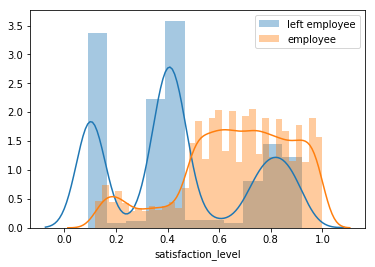

```python
sn.distplot(hr_df[hr_df.left==1].satisfaction_level, label="left employee")
sn.distplot(hr_df[hr_df.left==0].satisfaction_level,label="employee")
plt.legend();
```

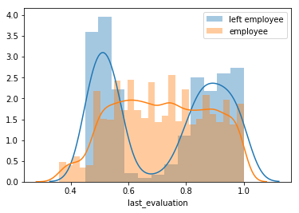

```python
sn.distplot(hr_df[hr_df.left==1].last_evaluation, label="left employee")
sn.distplot(hr_df[hr_df.left==0].last_evaluation,label="employee")
plt.legend();
```

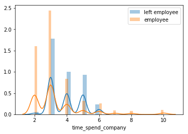

```python
sn.distplot(hr_df[hr_df.left==1].time_spend_company, label="left employee")
sn.distplot(hr_df[hr_df.left==0].time_spend_company,label="employee")
plt.legend();
```

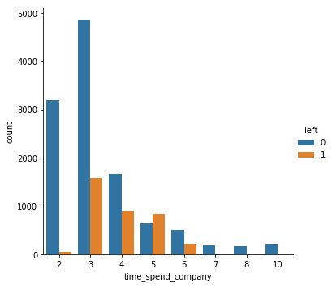

```python
sn.catplot(
    data=hr_df,
    x = 'time_spend_company',
    kind = 'count',
    hue = 'left'
);
```

1. last_evaluation is between 0.6 to 0.8 are less likely to leave
2. employee who has more than 6 years of experince are not levaing
3. employee who has job satishfaction less than 0.4 are more likely to leave

Classification meaning finding probablity of employee leaving:  
Probablity of employee leave = fn(x1,x2,...xn)

#### Problem in data we have categorical data in x which can not be put in mathemetical model

hr_df.salary.unique()

```python
hr_df.sales.unique()
```

```
array(['sales', 'accounting', 'hr', 'technical', 'support', 'management',
       'IT', 'product_mng', 'marketing', 'RandD'], dtype=object)
```

### Encoding Categorical variables

```python
hr_encoded_df = pd.get_dummies(
    hr_df,
    columns=['sales', 'salary']
)
```

```python
hr_encoded_df.head(2)
```

|  | satisfaction_level | last_evaluation | number_project | average_montly_hours | time_spend_company | Work_accident | left | promotion_last_5years | sales_IT | sales_RandD | ... | sales_hr | sales_management | sales_marketing | sales_product_mng | sales_sales | sales_support | sales_technical | salary_high | salary_low | salary_medium |
| --- | --- | --- | --- | --- | --- | --- | --- | --- | --- | --- | --- | --- | --- | --- | --- | --- | --- | --- | --- | --- | --- |
| 0 | 0.38 | 0.53 | 2 | 157 | 3 | 0 | 1 | 0 | 0 | 0 | ... | 0 | 0 | 0 | 0 | 1 | 0 | 0 | 0 | 1 | 0 |
| 1 | 0.80 | 0.86 | 5 | 262 | 6 | 0 | 1 | 0 | 0 | 0 | ... | 0 | 0 | 0 | 0 | 1 | 0 | 0 | 0 | 0 | 1 |

2 rows × 21 columns

```python
x_features = list(hr_encoded_df.columns)
```

```python
x_features.remove('left')
```

```python
x_features
```

```
['satisfaction_level',
 'last_evaluation',
 'number_project',
 'average_montly_hours',
 'time_spend_company',
 'Work_accident',
 'promotion_last_5years',
 'sales_IT',
 'sales_RandD',
 'sales_accounting',
 'sales_hr',
 'sales_management',
 'sales_marketing',
 'sales_product_mng',
 'sales_sales',
 'sales_support',
 'sales_technical',
 'salary_high',
 'salary_low',
 'salary_medium']
```

### Splitting dataset into train and test

```python
from sklearn.model_selection import train_test_split
x_train, x_test, y_train,y_test = train_test_split(
    hr_encoded_df[x_features],
    hr_encoded_df.left,
    train_size=0.8,
    random_state=100
);
```

```python
x_train.shape
```

```
(11999, 20)
```

```python
x_test.shape
```

```
(3000, 20)
```

### Building a model

```python
from sklearn.neighbors import KNeighborsClassifier
```

```python
from sklearn.model_selection import cross_val_score
scores_v1 = cross_val_score(
    KNeighborsClassifier(n_neighbors = 10),
    x_train,
    y_train,
    cv = 10
)
```

```python
scores_v1
```

```
array([0.94171524, 0.93833333, 0.93      , 0.94166667, 0.94583333,
       0.93416667, 0.93916667, 0.95      , 0.93661384, 0.94578816])
```

```python
scores_v1.mean() * 100
```

```
94.03283905636972
```

### Predict

```python
knn_v1 = KNeighborsClassifier(n_neighbors = 10)
knn_v1.fit(x_train, y_train)
```

```
KNeighborsClassifier(algorithm='auto', leaf_size=30, metric='minkowski',
           metric_params=None, n_jobs=None, n_neighbors=10, p=2,
           weights='uniform')
```

```python
y_pred_knn_v1 = knn_v1.predict(x_test)
```

```python
y_knn_v1 = pd.DataFrame({'actual':y_test, 'predicted': y_pred_knn_v1})
```

```python
y_knn_v1.sample(10)
```

|  | actual | predicted |
| --- | --- | --- |
| 4686 | 0 | 0 |
| 11019 | 0 | 0 |
| 4457 | 0 | 0 |
| 6464 | 0 | 0 |
| 3287 | 0 | 0 |
| 3543 | 0 | 1 |
| 11826 | 0 | 1 |
| 8582 | 0 | 0 |
| 1289 | 1 | 0 |
| 8196 | 0 | 0 |

```python
from sklearn.metrics import confusion_matrix
```

```python
cm_v1 = confusion_matrix(y_knn_v1.actual, y_knn_v1.predicted, [1,0])
```

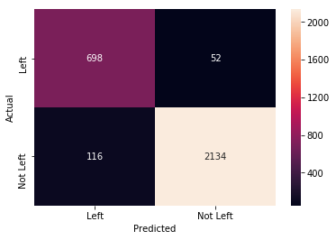

```python
sn.heatmap(
    cm_v1,
    fmt = "0.0f",
    xticklabels=["Left", "Not Left"],
    yticklabels=["Left", "Not Left"],
    annot= True
)
plt.xlabel("Predicted")
plt.ylabel("Actual");
```

```python
from sklearn.metrics import accuracy_score, log_loss
accuracy_score(y_knn_v1.actual, y_knn_v1.predicted)
```

```
0.944
```

```python
knn_v1.predict_proba(x_test)
```

```
array([[1. , 0. ],
       [1. , 0. ],
       [0. , 1. ],
       ...,
       [0.9, 0.1],
       [1. , 0. ],
       [1. , 0. ]])
```

```python
# Getting probabilty for 1 (leaving)
y_knn_v1['prob'] = knn_v1.predict_proba(x_test)[:,1]
```

```python
y_knn_v1.sample(10)
```

|  | actual | predicted | prob |
| --- | --- | --- | --- |
| 2996 | 0 | 0 | 0.2 |
| 3269 | 0 | 0 | 0.0 |
| 13584 | 0 | 0 | 0.0 |
| 12009 | 1 | 1 | 1.0 |
| 2522 | 0 | 0 | 0.0 |
| 4365 | 0 | 0 | 0.0 |
| 4332 | 0 | 0 | 0.0 |
| 9840 | 0 | 1 | 0.7 |
| 2820 | 0 | 0 | 0.2 |
| 3471 | 0 | 0 | 0.0 |

```python
y_knn_v1['new_predict'] = y_knn_v1.prob.map(lambda x: 1 if x > 0.2 else 0)
```

```python
cm_v2 = confusion_matrix(y_knn_v1.actual, y_knn_v1.new_predict, [1,0])
```

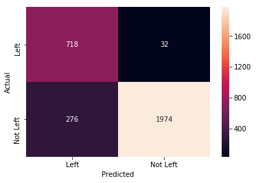

```python
sn.heatmap(
    cm_v2,
    fmt = "0.0f",
    xticklabels=["Left", "Not Left"],
    yticklabels=["Left", "Not Left"],
    annot= True
)
plt.xlabel("Predicted")
plt.ylabel("Actual");
```

### Note

Assign cost to False Negative and False Positive. Like in this case False Negative is 3 times costlier than False Positive. Because if person is Identify as not leaving company but actualy left new hiring process is costlier. So total cost to company due to false prediction is = [3(FN) + FP] = 372 Now we have to reduce this cost

#### Finding optimal cut off

```python
FP_COST = 1.0
FN_COST = 3.0
```

```python
def get_cost(cutoff):
    y_knn_v1['new_predict'] = y_knn_v1.prob.map(lambda x: 1 if x > cutoff else 0)
    cm = confusion_matrix(y_knn_v1.actual, y_knn_v1.new_predict, [1,0])
    cost = FN_COST * cm[0][1] + FP_COST * cm[1][0]
    return cost
```

```python
get_cost(0.2)
import numpy as np
cut_off_list = np.arange(0.1,0.8,0.01)
```

```python
cost_list = [get_cost(x) for x in cut_off_list]
```

```python
cost_df = pd.DataFrame({'cost': cost_list, 'cut_off': cut_off_list})
```

```python
cost_df.head(5)
```

|  | cost | cut_off |
| --- | --- | --- |
| 0 | 430.0 | 0.10 |
| 1 | 430.0 | 0.11 |
| 2 | 430.0 | 0.12 |
| 3 | 430.0 | 0.13 |
| 4 | 430.0 | 0.14 |

```python
cost_df.sort_values('cost', ascending=True)[0:2]
```

|  | cost | cut_off |
| --- | --- | --- |
| 34 | 267.0 | 0.44 |
| 31 | 267.0 | 0.41 |

```python
y_knn_v1['final_pred'] =  y_knn_v1.prob.map(lambda x: 1 if x > 0.41 else 0)
```

```python
cm_v3 = confusion_matrix(y_knn_v1.actual, y_knn_v1.final_pred, [1,0])
```

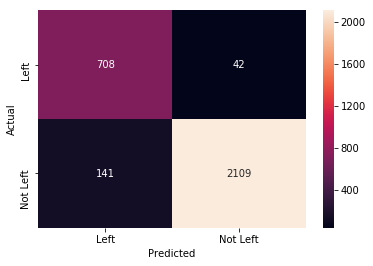

```python
sn.heatmap(
    cm_v3,
    fmt = "0.0f",
    xticklabels=["Left", "Not Left"],
    yticklabels=["Left", "Not Left"],
    annot= True
)
plt.xlabel("Predicted")
plt.ylabel("Actual");
```

#### Notes

Classification Model accuraccy: Precesion, Recall, F1-score  
Precesion = (TP/TP + FP)  
Recall/sensitivity = (TP/TP+FN)  
Depends of what qundrant is important to business use Precesion or Recall  
F1 Score = (2PR/P+R)  
Use F1 if both qundrant is important

Recall or sensitivity gives us information about a model’s performance on false negatives (incorrect prediction of customers who will default), while precision gives us information of the model’s performance of false positives. Based on what is predicted, precision or recall might be more critical for a model.

The cost function comes into play in deciding which of the incorrect predictions can be more detrimental — the false positive or the false negative (in other words, which performance measure is important — precision or recall). https://towardsdatascience.com/model-performance-cost-functions-for-classification-models-a7b1b00ba60

```python
from sklearn.metrics import classification_report
```

```python
print(classification_report(y_knn_v1.actual, y_knn_v1.final_pred))
```

```
              precision    recall  f1-score   support

           0       0.98      0.94      0.96      2250
           1       0.83      0.94      0.89       750

   micro avg       0.94      0.94      0.94      3000
   macro avg       0.91      0.94      0.92      3000
weighted avg       0.94      0.94      0.94      3000
```

## Decesion Tree

```python
from sklearn.tree import DecisionTreeClassifier
```

```python
tree_v1 = DecisionTreeClassifier(max_depth=5)
```

```python
tree_v1.fit(x_train, y_train)
```

```
DecisionTreeClassifier(class_weight=None, criterion='gini', max_depth=5,
            max_features=None, max_leaf_nodes=None,
            min_impurity_decrease=0.0, min_impurity_split=None,
            min_samples_leaf=1, min_samples_split=2,
            min_weight_fraction_leaf=0.0, presort=False, random_state=None,
            splitter='best')
```

```python
y_pred_tree_v1 = tree_v1.predict(x_test)
```

```python
cm_tree_v1 = confusion_matrix(y_test, y_pred_tree_v1, [1,0])
```

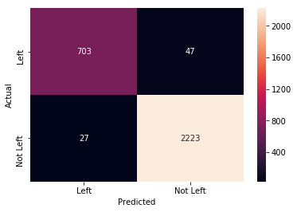

```python
sn.heatmap(
    cm_tree_v1,
    fmt = "0.0f",
    xticklabels=["Left", "Not Left"],
    yticklabels=["Left", "Not Left"],
    annot= True
)
plt.xlabel("Predicted")
plt.ylabel("Actual");
```

```python
print(classification_report(y_test, y_pred_tree_v1))
```

```
              precision    recall  f1-score   support

           0       0.98      0.99      0.98      2250
           1       0.96      0.94      0.95       750

   micro avg       0.98      0.98      0.98      3000
   macro avg       0.97      0.96      0.97      3000
weighted avg       0.98      0.98      0.98      3000
```

```python
from sklearn.tree import export_graphviz
```

```python
export_graphviz(
    tree_v1,
    out_file='tree.odt',
    feature_names=x_features,
    class_names=['Not Left', 'Left'],
    filled = True
)
```

```python
import pydotplus as pdot
```

```python
tree_graph = pdot.graphviz.graph_from_dot_file("tree.odt")
```

```python
tree_graph.write_png('tree.png')
```

```
True
```

```python
from IPython.display import Image
```

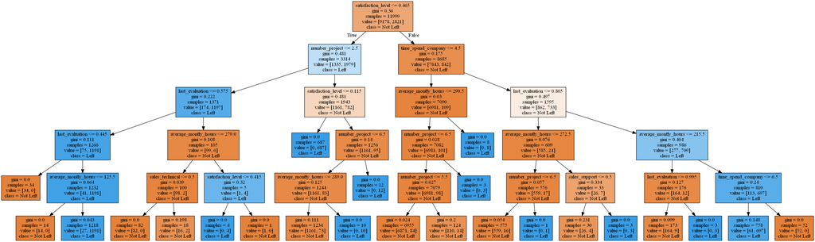

```python
Image(filename="tree.png")
```

### FInding model using Grid Search

```python
tree_v2 = DecisionTreeClassifier()
```

```python
from sklearn.model_selection import GridSearchCV
```

```python
tree_params = {'max_depth': range(3,11),
               'criterion': ["entropy", "gini"]
              }
```

```python
tree_grid = GridSearchCV(tree_v2, param_grid=tree_params, cv=10, scoring='recall') # cv=10 means 10 folds
```

```python
tree_grid.fit(x_train,y_train)
```

```
GridSearchCV(cv=10, error_score='raise-deprecating',
       estimator=DecisionTreeClassifier(class_weight=None, criterion='gini', max_depth=None,
            max_features=None, max_leaf_nodes=None,
            min_impurity_decrease=0.0, min_impurity_split=None,
            min_samples_leaf=1, min_samples_split=2,
            min_weight_fraction_leaf=0.0, presort=False, random_state=None,
            splitter='best'),
       fit_params=None, iid='warn', n_jobs=None,
       param_grid={'max_depth': range(3, 11), 'criterion': ['entropy', 'gini']},
       pre_dispatch='2*n_jobs', refit=True, return_train_score='warn',
       scoring='recall', verbose=0)
```

```python
tree_grid.best_params_
```

```
{'criterion': 'gini', 'max_depth': 10}
```

```python
tree_grid.best_score_
```

```
0.9404461049731572
```

```python
tree_v3 = tree_grid.best_estimator_
```

```python
from sklearn.neighbors import KNeighborsClassifier
knn_v1 = KNeighborsClassifier()
```

```python
kn_params = {'n_neighbors': range(5,15),
               'metric': ["minkowski", "euclidean"]
              }
```

```python
tree_grid = GridSearchCV(knn_v1, param_grid=kn_params, cv=10, scoring='recall') # cv=10 means 10 folds
```

```python
tree_grid.fit(x_train,y_train)
```

```
GridSearchCV(cv=10, error_score='raise-deprecating',
       estimator=KNeighborsClassifier(algorithm='auto', leaf_size=30, metric='minkowski',
           metric_params=None, n_jobs=None, n_neighbors=5, p=2,
           weights='uniform'),
       fit_params=None, iid='warn', n_jobs=None,
       param_grid={'n_neighbors': range(5, 15), 'metric': ['minkowski', 'euclidean']},
       pre_dispatch='2*n_jobs', refit=True, return_train_score='warn',
       scoring='recall', verbose=0)
```

```python
tree_grid.best_params_
```

```
{'metric': 'minkowski', 'n_neighbors': 13}
```

```python
tree_grid.best_score_
```

```
0.9195358760411952
```